# Chess Text File

John Cruz

2023-02-13

## Introduction

The objective is to import a text file containing the results of a chess tournament, extract the information needed, and export to a CSV file that could be used in a database.

A preview of the text file being used

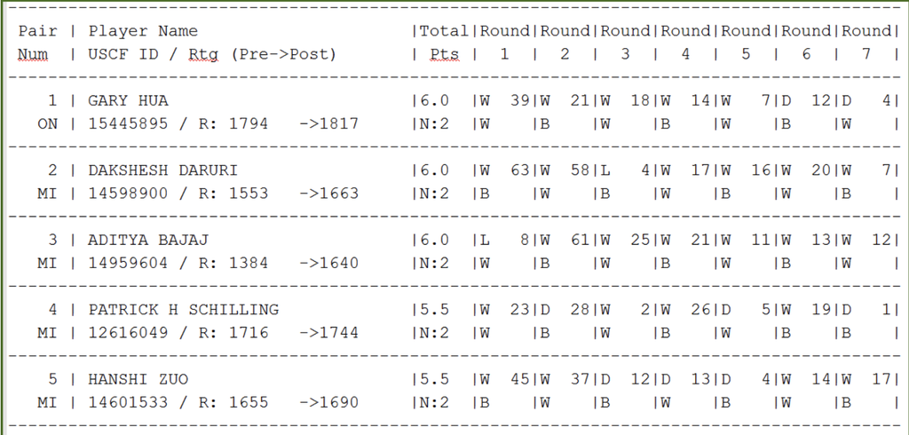

## Data Dictionary

| Column | Description |
| --- | --- |
| player_name | player’s full name |
| player_state | player’s state |
| total_pts | total points |
| pre-rating | player’s pre-rating entering the tournament |
| avg_opp_rating | average pre-rating of opponents entering the tournament |

## Required Libraries

```r
library(tidyverse)
library(stringr)
library(ggrepel)
```

## Read Text File

This will import the text file, reading each line individually and appending it to a DataFrame.

```r
df <- data.frame()

con = file('data.txt', "r")
while (TRUE) {
  line = readLines(con, n = 1)

  if (length(line) == 0) {
     break
  }

  df <- bind_rows(df, data.frame(line))
}
close(con)
```

The output of the DataFrame looks like this.

| line |
| --- |
| —————————————————————————————– |
| Pair \| Player Name \|Total\|Round\|Round\|Round\|Round\|Round\|Round\|Round\| |
| Num \| USCF ID / Rtg (Pre->Post) \| Pts \| 1 \| 2 \| 3 \| 4 \| 5 \| 6 \| 7 \| |
| —————————————————————————————– |
| 1 \| GARY HUA \|6.0 \|W 39\|W 21\|W 18\|W 14\|W 7\|D 12\|D 4\| |
| ON \| 15445895 / R: 1794 ->1817 \|N:2 \|W \|B \|W \|B \|W \|B \|W \| |

## Drop Non-Alphanumeric Rows

The next step is to remove rows in the DataFrame that does not provide any useful information at all, such as rows only containing “—”. Using *str_detect()*, I looked for rows containing at least some form of alphanumeric values within it.

```r
# find rows that has alpha-numeric characters
for (row in df){
  df$str_alpha <- str_detect(row, '[a-zA-Z0-9]')
}
```

We can see which rows were alphanumeric and which ones were not

| line | str_alpha |
| --- | --- |
| —————————————————————————————– | FALSE |
| Pair \| Player Name \|Total\|Round\|Round\|Round\|Round\|Round\|Round\|Round\| | TRUE |
| Num \| USCF ID / Rtg (Pre->Post) \| Pts \| 1 \| 2 \| 3 \| 4 \| 5 \| 6 \| 7 \| | TRUE |
| —————————————————————————————– | FALSE |
| 1 \| GARY HUA \|6.0 \|W 39\|W 21\|W 18\|W 14\|W 7\|D 12\|D 4\| | TRUE |
| ON \| 15445895 / R: 1794 ->1817 \|N:2 \|W \|B \|W \|B \|W \|B \|W \| | TRUE |

Now lets drop these rows and the header rows we do not need

```r
# drop non-alpha-numeric rows
df_alpha_num <- df %>%
  filter(., str_alpha == TRUE) %>%
  select(., line)

# drop first two rows containing header info
df_alpha_num <- df_alpha_num %>%
  slice(-c(1, 2))
```

Here is the output contaning only the player information

| line |
| --- |
| 1 \| GARY HUA \|6.0 \|W 39\|W 21\|W 18\|W 14\|W 7\|D 12\|D 4\| |
| ON \| 15445895 / R: 1794 ->1817 \|N:2 \|W \|B \|W \|B \|W \|B \|W \| |
| 2 \| DAKSHESH DARURI \|6.0 \|W 63\|W 58\|L 4\|W 17\|W 16\|W 20\|W 7\| |
| MI \| 14598900 / R: 1553 ->1663 \|N:2 \|B \|W \|B \|W \|B \|W \|B \| |
| 3 \| ADITYA BAJAJ \|6.0 \|L 8\|W 61\|W 25\|W 21\|W 11\|W 13\|W 12\| |
| MI \| 14959604 / R: 1384 ->1640 \|N:2 \|W \|B \|W \|B \|W \|B \|W \| |

## Extract Player Data

Every two rows contains a individual’s tournament information. The DataFrame will be parsed between “|” characters and added into individual columns for each player. The columns of interest will then be selected and placed into a new DataFrame.

```r
# create empty dataframe
player_df <- data.frame()

# loop through each row
for (i in seq(1, nrow(df_alpha_num), by = 2)){

  # read every odd row for player id, name and total points
  row_info <- str_split_fixed(df_alpha_num[i, ],regex("|", literal=TRUE),n=Inf)
  df_temp <- data.frame(row_info)
  temp_cols <- c("player_id", "player_name", "total_pts", "round_1", "round_2", "round_3", "round_4", "round_5", "round_6", "round_7")
  colnames(df_temp) = temp_cols
  df_export <- df_temp %>%
      select(1:10)

  # read every even row to add additional columns for player info state and pre-rating
  row_info <- str_split_fixed(df_alpha_num[i+1, ],regex("|", literal=TRUE),n=Inf)
  df_temp <- data.frame(row_info)
  temp_cols <- c("player_state", "pre_rating")
  colnames(df_temp) = temp_cols
  df_export <- bind_cols(df_export, df_temp %>%
      select(1:2))

  # extract individual player info to all players dataframe
  player_df <- bind_rows(player_df, df_export)
}
```

Here we can see an example of how the information was separated

| player_state | pre_rating | NA | NA | NA | NA | NA | NA | NA | NA | NA |
| --- | --- | --- | --- | --- | --- | --- | --- | --- | --- | --- |
| MI | 15006561 / R: 1163 ->1112 |  | B | W | W | B | W | B | B |  |

Finally, we get a DataFrame that begins to look more manageable to work with

| player_id | player_name | total_pts | round_1 | round_2 | round_3 | round_4 | round_5 | round_6 | round_7 | player_state | pre_rating |
| --- | --- | --- | --- | --- | --- | --- | --- | --- | --- | --- | --- |
| 1 | GARY HUA | 6.0 | W 39 | W 21 | W 18 | W 14 | W 7 | D 12 | D 4 | ON | 15445895 / R: 1794 ->1817 |
| 2 | DAKSHESH DARURI | 6.0 | W 63 | W 58 | L 4 | W 17 | W 16 | W 20 | W 7 | MI | 14598900 / R: 1553 ->1663 |
| 3 | ADITYA BAJAJ | 6.0 | L 8 | W 61 | W 25 | W 21 | W 11 | W 13 | W 12 | MI | 14959604 / R: 1384 ->1640 |
| 4 | PATRICK H SCHILLING | 5.5 | W 23 | D 28 | W 2 | W 26 | D 5 | W 19 | D 1 | MI | 12616049 / R: 1716 ->1744 |
| 5 | HANSHI ZUO | 5.5 | W 45 | W 37 | D 12 | D 13 | D 4 | W 14 | W 17 | MI | 14601533 / R: 1655 ->1690 |
| 6 | HANSEN SONG | 5.0 | W 34 | D 29 | L 11 | W 35 | D 10 | W 27 | W 21 | OH | 15055204 / R: 1686 ->1687 |

## Clean Strings

We can see that some of the columns need to be further cleaned because they contain more information than needed. The next step was removing the decision such as “W” for win, and solely keeping the numeric value as it tells us the player ID of the person they played that round.

```r
for (i in 4:10){
  player_df[, i] <- gsub("[^0-9]", "", player_df[, i])
}
```

Next, the player’s pre-rating is right after the “:” but before “<-”. For example, in “14959604 / R: 1384 ->1640”, 1384 would be the player’s pre-rating. The number will be extracted using *parse_number()*

```r
player_df <- player_df %>%
  separate_wider_delim(pre_rating, delim = ": ", names = c('rtg_1', 'rtg_2'))

player_df$pre_rating <- player_df$rtg_2 %>% parse_number()
```

This will remove preceding and following whitespaces in a string throughout the DataFrame.

```r
player_df <- player_df %>%
  mutate(across(where(is.character), str_trim))
```

Finally, the columns data types were change where appropriately needed.

```r
change_type <- c("player_id", "total_pts", "round_1", "round_2", "round_3", "round_4", "round_5", "round_6", "round_7", "pre_rating")
player_df <- player_df %>%
  mutate_at(change_type, as.numeric)
```

The DataFrame now looks like this.

| player_id | player_name | total_pts | round_1 | round_2 | round_3 | round_4 | round_5 | round_6 | round_7 | player_state | rtg_1 | rtg_2 | pre_rating |
| --- | --- | --- | --- | --- | --- | --- | --- | --- | --- | --- | --- | --- | --- |
| 1 | GARY HUA | 6.0 | 39 | 21 | 18 | 14 | 7 | 12 | 4 | ON | 15445895 / R | 1794 ->1817 | 1794 |
| 2 | DAKSHESH DARURI | 6.0 | 63 | 58 | 4 | 17 | 16 | 20 | 7 | MI | 14598900 / R | 1553 ->1663 | 1553 |
| 3 | ADITYA BAJAJ | 6.0 | 8 | 61 | 25 | 21 | 11 | 13 | 12 | MI | 14959604 / R | 1384 ->1640 | 1384 |
| 4 | PATRICK H SCHILLING | 5.5 | 23 | 28 | 2 | 26 | 5 | 19 | 1 | MI | 12616049 / R | 1716 ->1744 | 1716 |
| 5 | HANSHI ZUO | 5.5 | 45 | 37 | 12 | 13 | 4 | 14 | 17 | MI | 14601533 / R | 1655 ->1690 | 1655 |
| 6 | HANSEN SONG | 5.0 | 34 | 29 | 11 | 35 | 10 | 27 | 21 | OH | 15055204 / R | 1686 ->1687 | 1686 |

## Determine Opponents Average Pre-Ratings

As mentioned before, each round column contains the opponent they played. Now, that opponent’s player ID will be replaced with the opponent’s pre-rating instead. This is so we can calculate the opponent’s average pre-rating for the player.

```r
for (i in 1:nrow(player_df)){
  for (j in 4:10){
    if (!is.na(player_df[[i,j]])){
      player_df[i,j] <- player_df %>%
        filter(., player_id == player_df[[i, j]]) %>%
        select(pre_rating)
    }
  }
}
```

| player_id | player_name | total_pts | round_1 | round_2 | round_3 | round_4 | round_5 | round_6 | round_7 | player_state | rtg_1 | rtg_2 | pre_rating |
| --- | --- | --- | --- | --- | --- | --- | --- | --- | --- | --- | --- | --- | --- |
| 1 | GARY HUA | 6.0 | 1436 | 1563 | 1600 | 1610 | 1649 | 1663 | 1716 | ON | 15445895 / R | 1794 ->1817 | 1794 |
| 2 | DAKSHESH DARURI | 6.0 | 1175 | 917 | 1716 | 1629 | 1604 | 1595 | 1649 | MI | 14598900 / R | 1553 ->1663 | 1553 |
| 3 | ADITYA BAJAJ | 6.0 | 1641 | 955 | 1745 | 1563 | 1712 | 1666 | 1663 | MI | 14959604 / R | 1384 ->1640 | 1384 |
| 4 | PATRICK H SCHILLING | 5.5 | 1363 | 1507 | 1553 | 1579 | 1655 | 1564 | 1794 | MI | 12616049 / R | 1716 ->1744 | 1716 |
| 5 | HANSHI ZUO | 5.5 | 1242 | 980 | 1663 | 1666 | 1716 | 1610 | 1629 | MI | 14601533 / R | 1655 ->1690 | 1655 |
| 6 | HANSEN SONG | 5.0 | 1399 | 1602 | 1712 | 1438 | 1365 | 1552 | 1563 | OH | 15055204 / R | 1686 ->1687 | 1686 |

Here, we finally calculate the average opponent pre-rating

```r
player_df <- player_df %>%
  mutate(avg_opp_pre_rating = round(rowMeans(pick(round_1:round_7), na.rm=TRUE), 2))
```

| player_id | player_name | total_pts | round_1 | round_2 | round_3 | round_4 | round_5 | round_6 | round_7 | player_state | rtg_1 | rtg_2 | pre_rating | avg_opp_pre_rating |
| --- | --- | --- | --- | --- | --- | --- | --- | --- | --- | --- | --- | --- | --- | --- |
| 1 | GARY HUA | 6.0 | 1436 | 1563 | 1600 | 1610 | 1649 | 1663 | 1716 | ON | 15445895 / R | 1794 ->1817 | 1794 | 1605.29 |
| 2 | DAKSHESH DARURI | 6.0 | 1175 | 917 | 1716 | 1629 | 1604 | 1595 | 1649 | MI | 14598900 / R | 1553 ->1663 | 1553 | 1469.29 |
| 3 | ADITYA BAJAJ | 6.0 | 1641 | 955 | 1745 | 1563 | 1712 | 1666 | 1663 | MI | 14959604 / R | 1384 ->1640 | 1384 | 1563.57 |
| 4 | PATRICK H SCHILLING | 5.5 | 1363 | 1507 | 1553 | 1579 | 1655 | 1564 | 1794 | MI | 12616049 / R | 1716 ->1744 | 1716 | 1573.57 |
| 5 | HANSHI ZUO | 5.5 | 1242 | 980 | 1663 | 1666 | 1716 | 1610 | 1629 | MI | 14601533 / R | 1655 ->1690 | 1655 | 1500.86 |
| 6 | HANSEN SONG | 5.0 | 1399 | 1602 | 1712 | 1438 | 1365 | 1552 | 1563 | OH | 15055204 / R | 1686 ->1687 | 1686 | 1518.71 |

## Export to CSV

Now that we have the data we want, we can export the columns of interest to CSV.

```r
export_df <- player_df %>%
  select(-c(1, 4:10, 12, 13)) %>%
  select(c(1, 3, 2, 4, 5))

write_csv(export_df, 'chess_players.csv')
```

| player_name | player_state | total_pts | pre_rating | avg_opp_pre_rating |
| --- | --- | --- | --- | --- |
| GARY HUA | ON | 6.0 | 1794 | 1605.29 |
| DAKSHESH DARURI | MI | 6.0 | 1553 | 1469.29 |
| ADITYA BAJAJ | MI | 6.0 | 1384 | 1563.57 |
| PATRICK H SCHILLING | MI | 5.5 | 1716 | 1573.57 |
| HANSHI ZUO | MI | 5.5 | 1655 | 1500.86 |
| HANSEN SONG | OH | 5.0 | 1686 | 1518.71 |

## Conclusion

Calculating the pre-rating difference between the player and average player rating, we can see some players had a tougher road to reach the top in total points earned. Aditya Bajaj had the largest difference of almost -180 pre-rating to their average opponent, yet collected 6.0 total points.

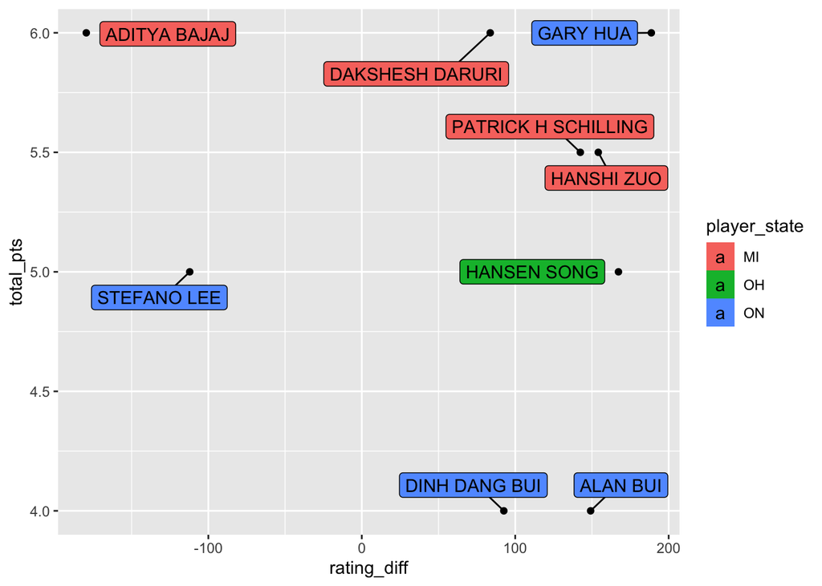

| player_name | player_state | total_pts | rating_diff |
| --- | --- | --- | --- |
| ADITYA BAJAJ | MI | 6.0 | -179.57 |
| DAKSHESH DARURI | MI | 6.0 | 83.71 |
| GARY HUA | ON | 6.0 | 188.71 |
| PATRICK H SCHILLING | MI | 5.5 | 142.43 |
| HANSHI ZUO | MI | 5.5 | 154.14 |
| STEFANO LEE | ON | 5.0 | -112.14 |
| HANSEN SONG | OH | 5.0 | 167.29 |
| DINH DANG BUI | ON | 4.0 | 92.57 |
| ALAN BUI | ON | 4.0 | 149.14 |

## Recommendations

Reviewing the methods used, alternatives along the way could have been done. Utilizing regular expressions and creating flexibility on the column headers. This would allow us to create a DataFrame that collected all the data provided in long format.